# Projet Statistique

Rédigé par Berrebi Nathane et Serge Arthur et encadré par Sportisse Aude

# Sommaire

## I- Introduction

## II- Analyse univariée

## III- Analyse bivariée

## IV- Régression linéaire simple

## V- Régression linéaire multiple

## VI- ANOVA

## VII- Conclusion

# Introduction

L’objet de cette étude est d’analyser la base de données *The boston HMDA*, qui recense les cas d’autorisation de prêts bancaires, selon la loi américaine, dans le cadre d’une transaction hypothécaire. Le jeu de données contient 2381 observations et 13 variables.

- Dir : dette / revenu total
- Hir : Frais de logements / revenu total
- lvr : rapport entre la taille du prêt et la valeur estimée du bien
- ccs : côte de crédit à la consommation de 1 à 6 (une faible valeur étant une bonne cote)
- mcs : côte de crédit hypothécaire de 1 à 4 (une faible valeur étant une bonne cote)
- pbcr : dossier de mauvais crédit public?
- dmi : assurance hypothécaire refusée?
- self : travailleur indépendant ?
- single : le demandeur est-il célibataire?
- Uria: 1989 Taux de chômage dans le secteur de la requérante dans le Massachusetts
- condominium : l’unité est-elle un condominium?
- Black: le demandeur est-il noir?
- deny: demande d’hypothèque refusée?

# Analyse univariée

Nous ne présentons pas toutes les variables qualitatives car celles-ci sont trop nombreuses, mais l’étude de chacune a été globalement similaire. De plus, certains graphes qui seront traités ne seront pas affichés.

## Variables continues

### Dir

C’est la variable **Dir** que nous tentons de prédire tout le long de cette étude.

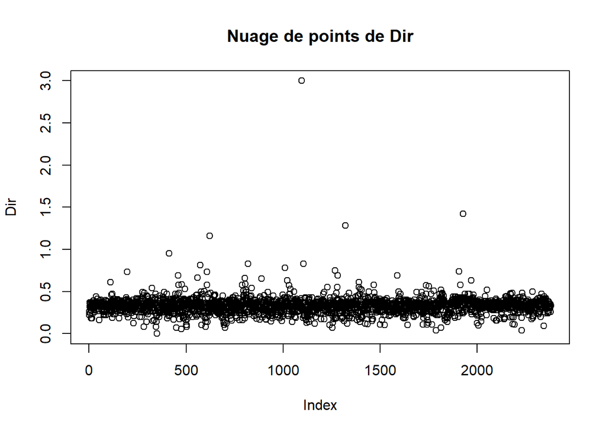

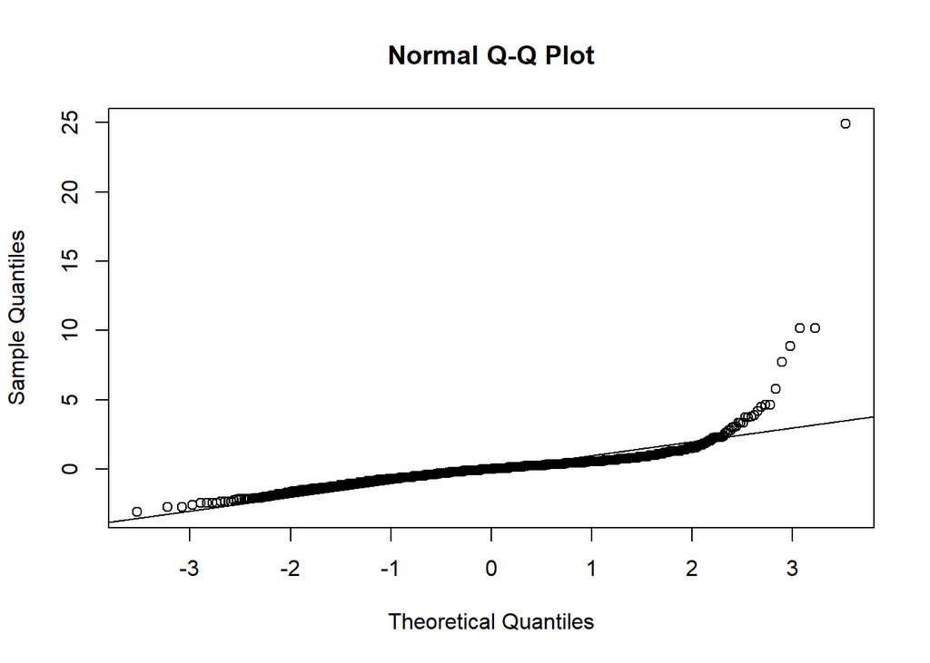

L’histogramme et la fonction de répartition indiquent à première vue un lien entre la distribution de *Dir* est celle d’une loi Normale, celle ci semble symétrique et la loi est clairement continue. Le qq-norm pourrait être pas mal si on supprimait les quelques valeurs significativement étranges.

Etudions la tendance centrale, qui ressort nettement de tous nos graphiques. Celle-ci a une moyenne qui se trouve autour du point 0.33 (estimé par la moyenne empirique) et la médiane empirique vaut aussi 0.33, ce qui corrobore l’hypothèse d’une loi symétrique.

Nous choisissons de supprimer à l’œil nu les quelques valeurs (au nombre de 5) qui nous semblent trop extrêmes (ce sont d’ailleurs des valeurs qui seront définies comme aberrantes plus tard).

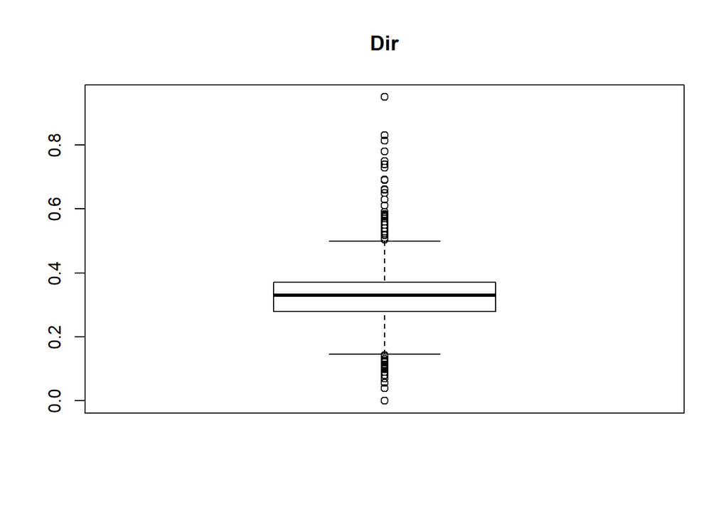

En supprimant quelques valeurs qui n’ont pas l’air de suivre la même distribution que les autres points, on remarque avec le nouveau qq-norm (qui n’est pas affiché) que ça ajuste plus une loi Normale; de plus le coefficient d’aplatissement a nettement baissé en supprimant ces quelques valeurs. On est passé de plus de 170 à 5.28. Mais ils semblerait d’après le boxplot que quelques valeurs aberrantes sont toujours présente dans les données, on pourrait donc approcher encore mieux une loi Normale en les supprimant aussi mais mieux vaut de ne pas trop “influencer les données”. L’hypothèse de la loi Normale est donc une option retenue pour cette variable.

### Hir

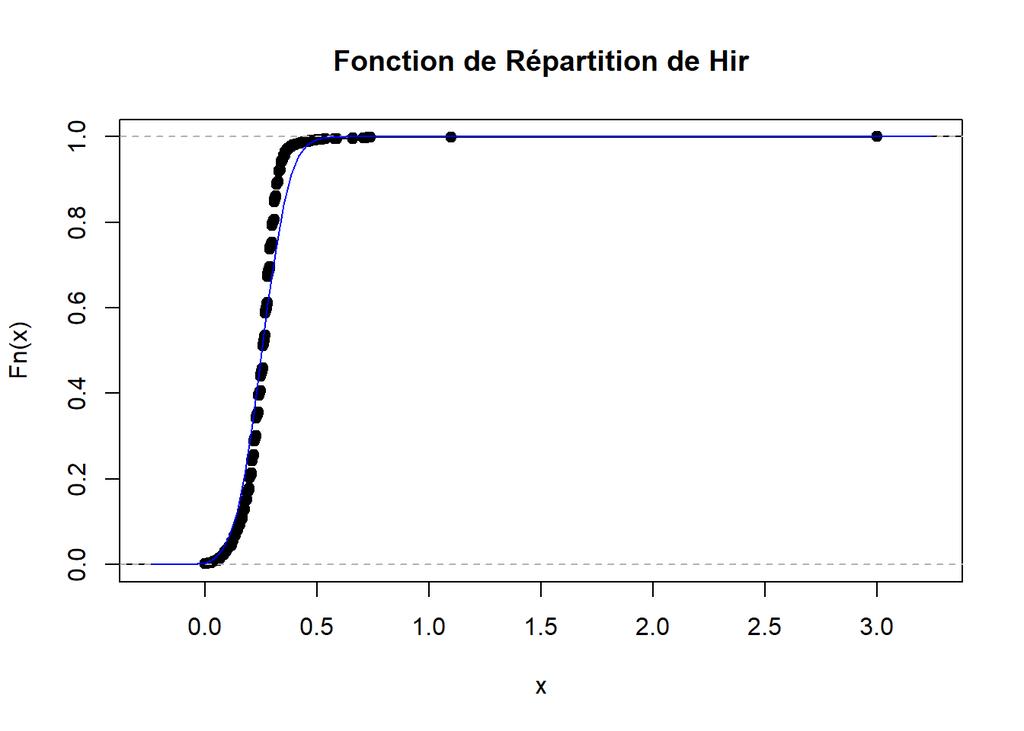

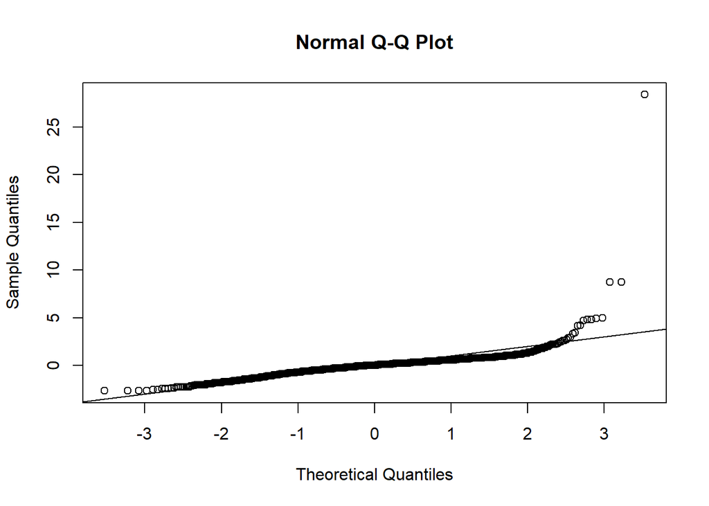

*Hir* est une variable continue (on le voit à l’aide de la fonction de répartition présentée plus haut). Le comportement de *Hir* est assez semblable à celui de *Dir*; on y retrouve une forte ressemblance avec une loi Normale malgré la présence de certains points qui viennent faire tâche. Analysons la distribution de *hir* en supprimant quelques valeurs.

Tout comme pour la variable *dir*, en supprimant certaines valeur on trouve que la distribution de *hir* est encore plus similaire à celle d’une loi Normale; de plus, le coefficient d’aplatissement est passé de 270 à 3.

### LVR

Concernant la variable *Lvr*, les même remarques peuvent être faites.

## Variables discrètes

### Uria

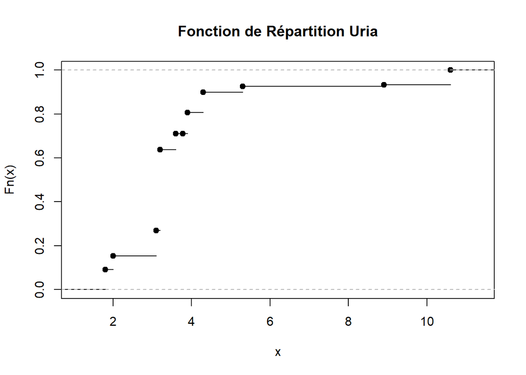

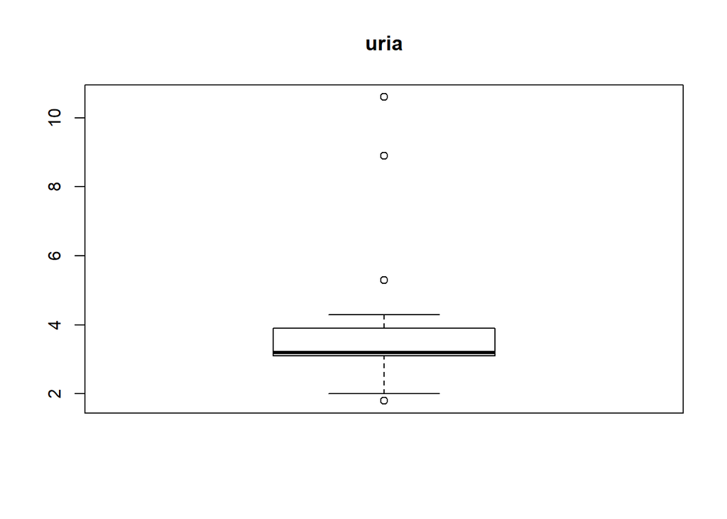

Au premier abord on pourrait croire que la variable *uria* est continue car elle représente le taux de chômage. Cependant on peut voir que la fonction de répartition empirique est fortement “étagée” et donc la variable *uria* prend un nombre fini de valeurs. D’où le choix de prendre la variable *uria* comme discrète.

### Deny

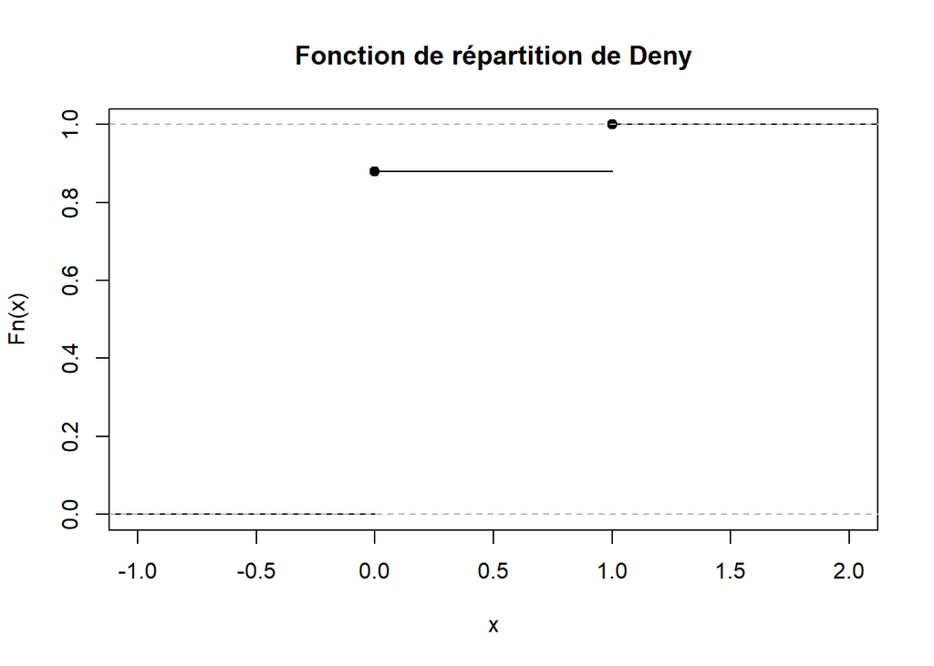

Nous tenterons donc d’estimer la variable *Dir* qui est le rapport entre la dette du demandeur du prêt avec ses revenus totaux.

# Analyse bivariée

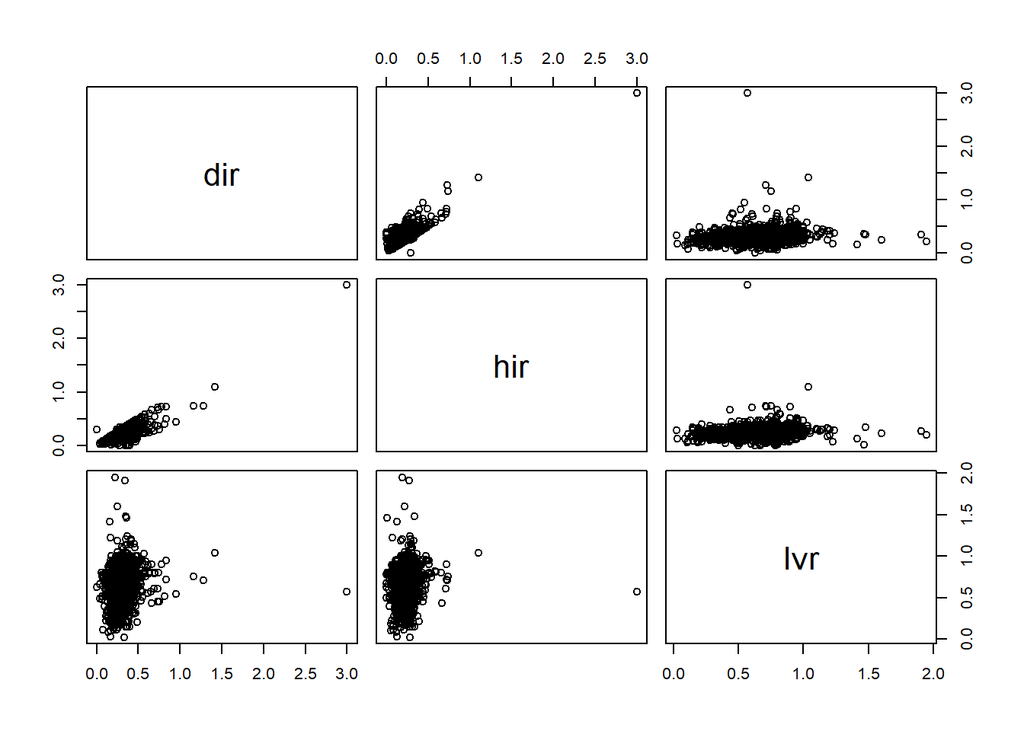

On remarque une forte corrélation entre *dir* et *hir* (le coefficient de corrélation est de 0.78 et leur points semblent à peu près s’aligner sur une droite). A l’inverse, la variable *lvr* est peu corrélée avec les deux autres variables (les coefficients de corrélations sont 0.156 avec *dir* et 0.12 avec *hir*). Dans l’objectif de faire une régression linéaire simple il vaut mieux, au premier abord, utiliser *hir* pour estimer *dir*. Nous vérifierons cette supposition en comparant les deux modèles.

# Régression Linéaire

### Régression Dir et Hir

```
##
## Call:
## lm(formula = data$dir ~ data$hir, data = data)
##
## Residuals:
##      Min       1Q   Median       3Q      Max
## -0.36087 -0.04883 -0.01064  0.03046  0.53757
##
## Coefficients:
##             Estimate Std. Error t value Pr(>|t|)
## (Intercept) 0.109380   0.003876   28.22   <2e-16 ***
## data$hir    0.867188   0.014195   61.09   <2e-16 ***
## ---
## Signif. codes:  0 '***' 0.001 '**' 0.01 '*' 0.05 '.' 0.1 ' ' 1
##
## Residual standard error: 0.06692 on 2379 degrees of freedom
## Multiple R-squared:  0.6107, Adjusted R-squared:  0.6105
## F-statistic:  3732 on 1 and 2379 DF,  p-value: < 2.2e-16
```

Les p-value associées aux tests de significativité de beta<sub>0</sub> et beta<sub>1</sub> sont tous les deux inférieurs à e<sup>16</sup>. On rejette donc H<sub>o</sub> sans scrupule pour les deux tests, on en conclut que les deux coefficients ont un réel impact.

Analysons donc cette régression, vérifie-t-elle les hypothèses du modèle linéaire Gaussien?

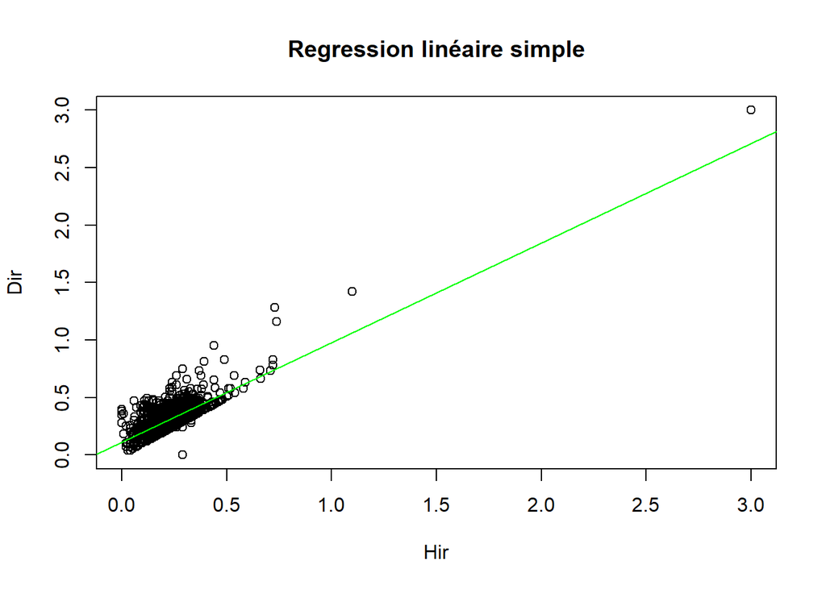

Tout d’abord on observe que la plupart des variables explicatives sont inférieur à 1 et que celles supérieur à 1 sont mal ajustés par le modèle, pour améliorer la régression, linéaire on peut supprimer les point levier quitte à se restreindre à un modèle linéaire local.

Analysons donc cest points qui nous semblent différents.

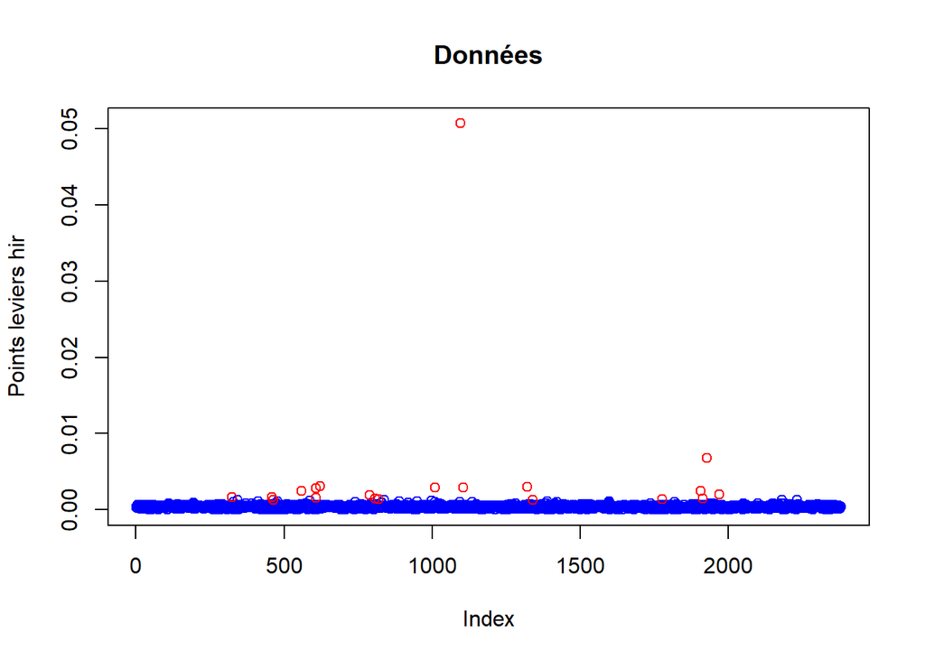

Comme prévu, les valeurs suspectes détectées depuis le départ sont bien des points leviers cependant on observe qu’il y a d’autres points leviers dont la valeur du coefficient diagonale associé est moins grande mais supérieur au seuil de 3*p/n (ici p=1).

Continuons en analysant les résidus studentisés et donc les valeurs aberrantes. D’après le théorème du cours, si les résidus εi suivent la loi normale N(0,σ2) , alors les résidus studentisés suivent la loi de Student T(n−p−1) . Commençons par calculer les quantiles d’ordre i/n de la loi T(n−p−1) , puis traçons un QQ-plot. Pour valider le modèle linéaire il faut que les erreurs soient gaussiennes et si c’est le cas alors les résidus studentisé suivent une loi de Student.

Il faudrait aussi en théorie montrer que X soit de rang plein mais on l’admettra pour cette étude.

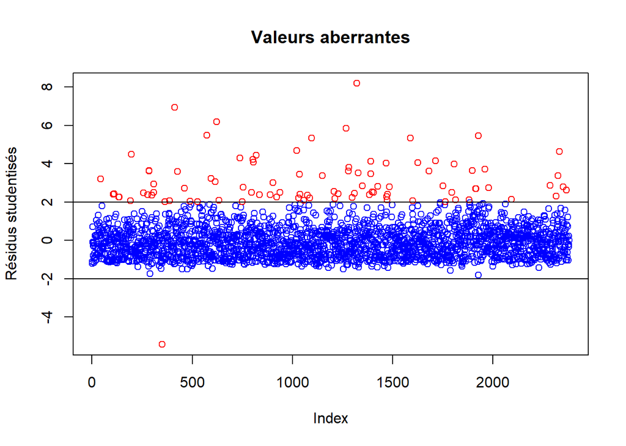

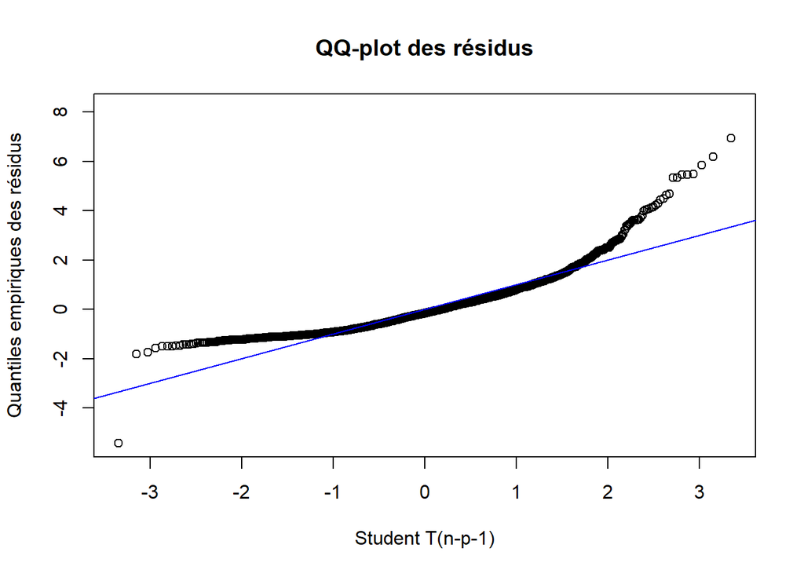

On peut constater qu’il y a beaucoup plus de valeurs aberrantes que de points leviers. Cependant les valeurs aberrantes sont les lignes du dataframe dont le coefficient studentisé associé appartient à la région de rejet du test, or le test est de niveaux 5, il est donc normal qu’environ 5% des valeurs soit rejeté. Dans notre cas on a 95 valeurs aberrantes, ce qui est inférieur au 5% attendus (~119), donc l’hypothèse de normalité des résidus semble être en bonne voie dans notre cas. Cependant, on sait que si les résidus εi suivent la loi normale N(0,σ2) , alors les résidus studentisés suivent la loi de Student T(n−p−1). Mais l’alignement des points sur la première bissectrice du QQ-plot est mauvais, ce qui infirme l’hypothèse selon laquelle les résidus théoriques εi suivent la loi normale N(0,σ2). L’hypothèse ne semble donc pas être vérifiée. Approfondissons un peu.

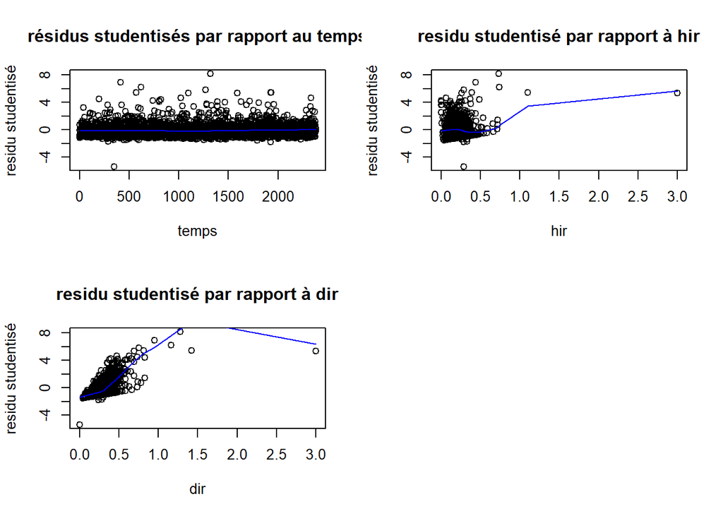

Les deux premiers graphes semblent montrer une indépendance des résidus studentisés, cependant sur le troisième graphe on remarque une tendance à la hausse et une forme de cône sur les résidus. Cela démontre un manque d’homoscédasticité des résidus. Une solution pourrait être de rajouter des variables explicatives.

Etudions à présent la distance de Cook.

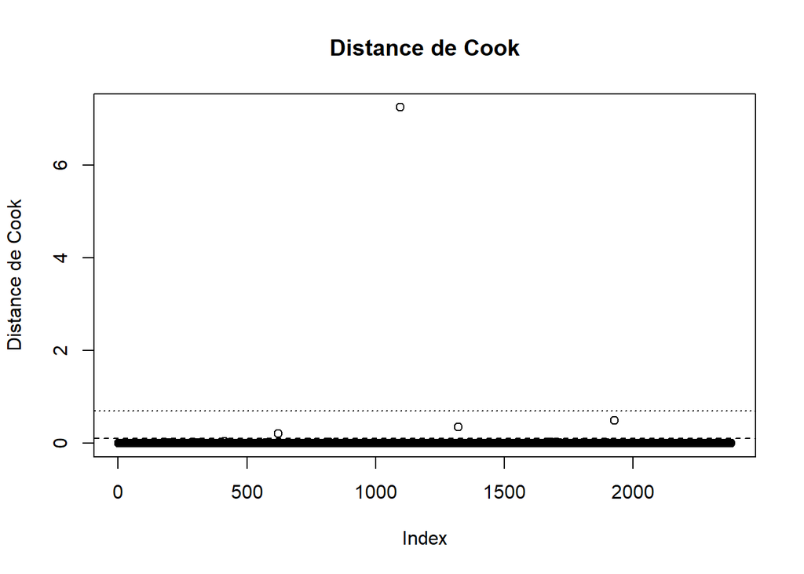

Voyons maintenant si la régression linéaire associé aux données “nettoyés” est meilleure. Afin de nettoyer, nous supprimons l’ensemble des valeurs aberrantes et les points levier. Nous rappelons qu’étant donné que de nombreuses valeurs supérieur à 1 ont était supprimé il est certain que le nouveau modèle va moins bien estimer les grande valeurs. mais pour faire des prédictions sur des valeurs en entrée entre 0 et 1 il est probable que le nouveau modèle soit meilleur.

[figure not shown]

#### Conclusion quant à ce premier modèle:

Le modèle proposé n’est pas parfait, le coefficient de corrélation est inférieur à 0.8, il y a quelques valeurs aberrantes. Cependant l’hypothèse du modèle linéaire reste possible, la droite de régression n’est pas parfaite mais reste convenable.

### Régression Dir et Lvr

```
##
## Call:
## lm(formula = dir ~ lvr, data = data)
##
## Residuals:
##      Min       1Q   Median       3Q      Max
## -0.32103 -0.04573 -0.00068  0.03956  2.68422
##
## Coefficients:
##             Estimate Std. Error t value Pr(>|t|)
## (Intercept) 0.264122   0.009232  28.610  < 2e-16 ***
## lvr         0.090397   0.012162   7.433 1.47e-13 ***
## ---
## Signif. codes:  0 '***' 0.001 '**' 0.01 '*' 0.05 '.' 0.1 ' ' 1
##
## Residual standard error: 0.106 on 2379 degrees of freedom
## Multiple R-squared:  0.0227, Adjusted R-squared:  0.02229
## F-statistic: 55.25 on 1 and 2379 DF,  p-value: 1.473e-13
```

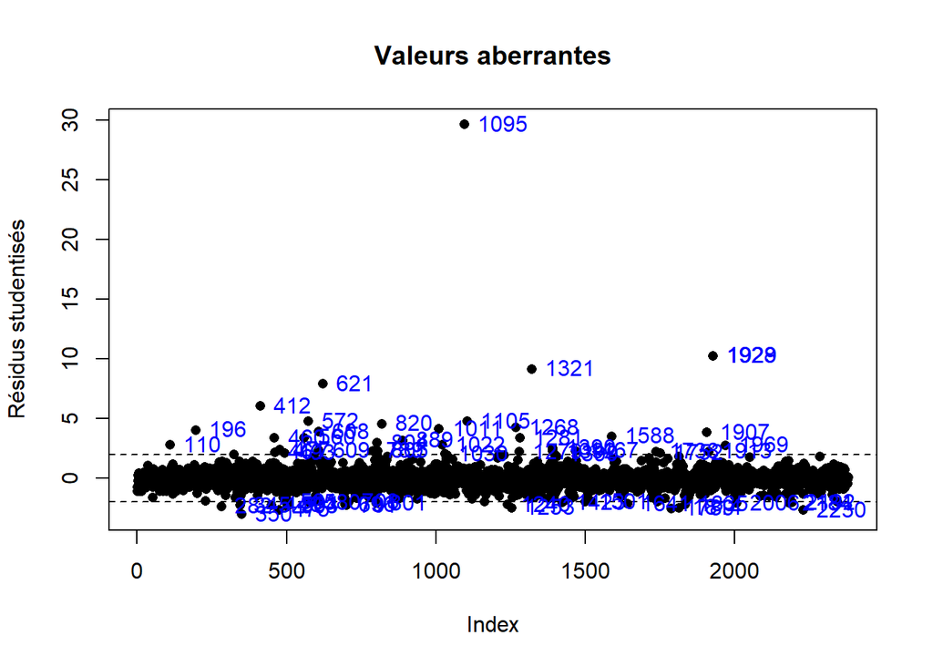

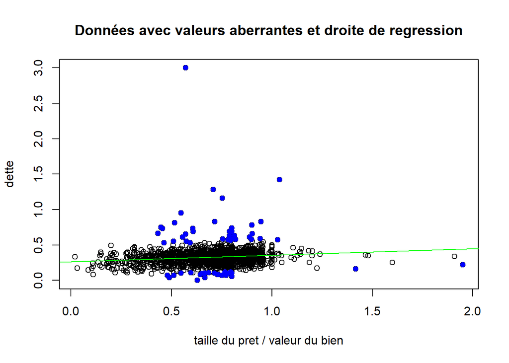

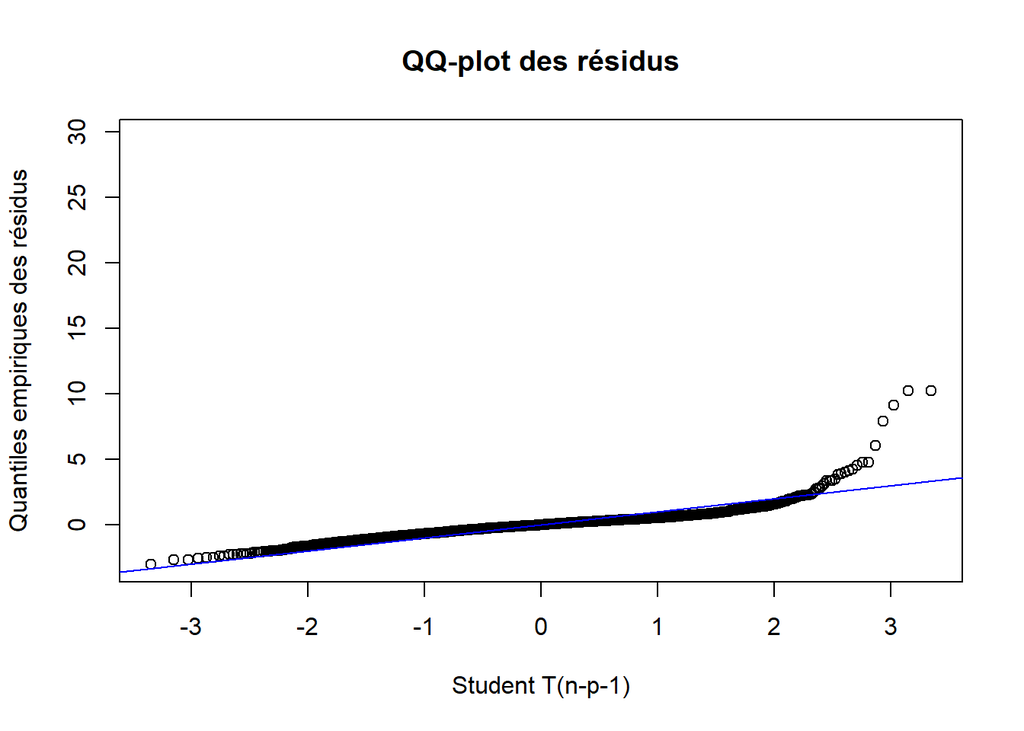

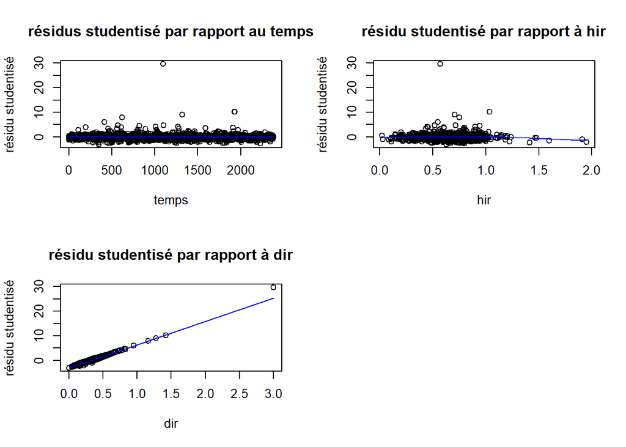

Dans ce modèle, on conclut que les résidus studentisés suivent une loi de Student, donc que les vrais résidus sont indépendants. On observe qu’il y a une tendance linéaire entre *dir* et les résidus studentisés, cela contredit l’hypothese d’ homoscédasticité. Cependant la linéarité de la tendance nous indique qu’il faudrait peut être faire une régression linéaire avec une transformation affine de *lvr*.

#### Comparaison des deux modèles

```
##         ModeleHir     ModeleLvr
## AIC -6.116542e+03 -3.924962e+03
## EQM  4.171447e-03  2.613254e-03
```

L’EQM donne une information sur la performance prédictive du modèle, alors que l’AIC donne un compromis entre la complexité du modèle et sa qualité.

Le modèle avec *Hir* comme variable explicative est meilleur au sens de l’AIC, et celui avec *Lvr* comme variable explicative est préférable au sens de la prédiction. Cependant les deux EQM sont très proches contrairement aux AIC.

## Régression linéaire multiple

Dans notre jeu de données nous avons 3 variables quantitatives *dir*, *hir* et *lvr*. Pour prédire *dir* avec un modèle linéaire multiple, la seule combinaison de variables explicatives possible est hir+lvr. Il n’est donc pas intéressant de faire une sélection de variables.

```
##
## Call:
## lm(formula = dir ~ hir + lvr, data = data)
##
## Residuals:
##      Min       1Q   Median       3Q      Max
## -0.35718 -0.04768 -0.01017  0.02943  0.54204
##
## Coefficients:
##             Estimate Std. Error t value Pr(>|t|)
## (Intercept) 0.087889   0.006502  13.518  < 2e-16 ***
## hir         0.859788   0.014262  60.284  < 2e-16 ***
## lvr         0.031692   0.007712   4.109  4.1e-05 ***
## ---
## Signif. codes:  0 '***' 0.001 '**' 0.01 '*' 0.05 '.' 0.1 ' ' 1
##
## Residual standard error: 0.0667 on 2378 degrees of freedom
## Multiple R-squared:  0.6134, Adjusted R-squared:  0.6131
## F-statistic:  1887 on 2 and 2378 DF,  p-value: < 2.2e-16
```

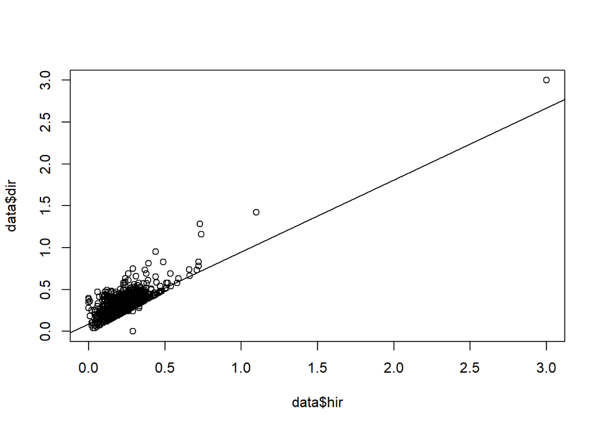

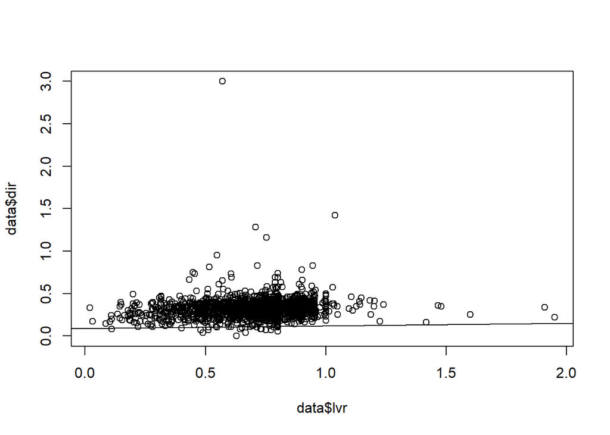

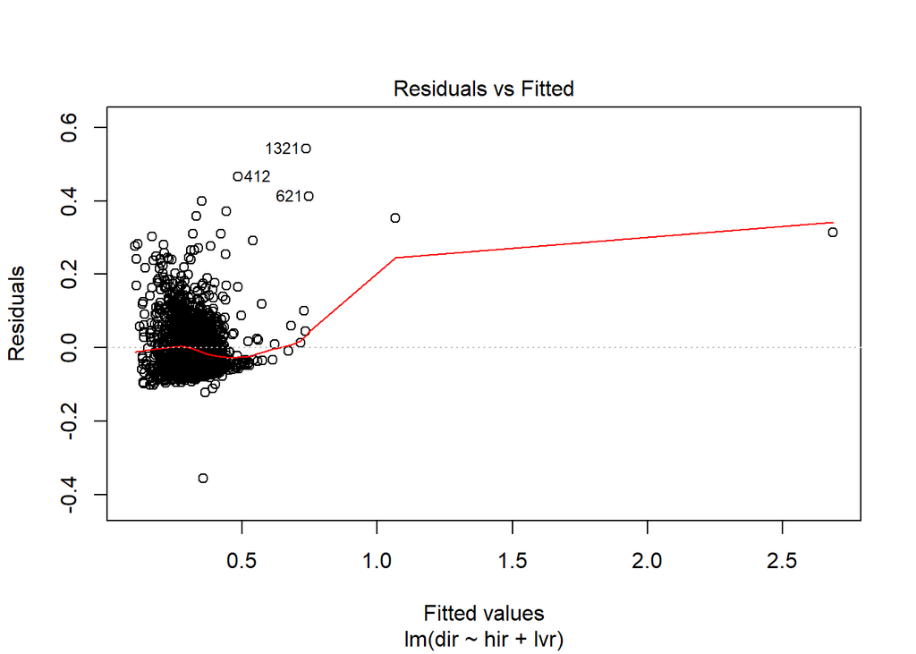

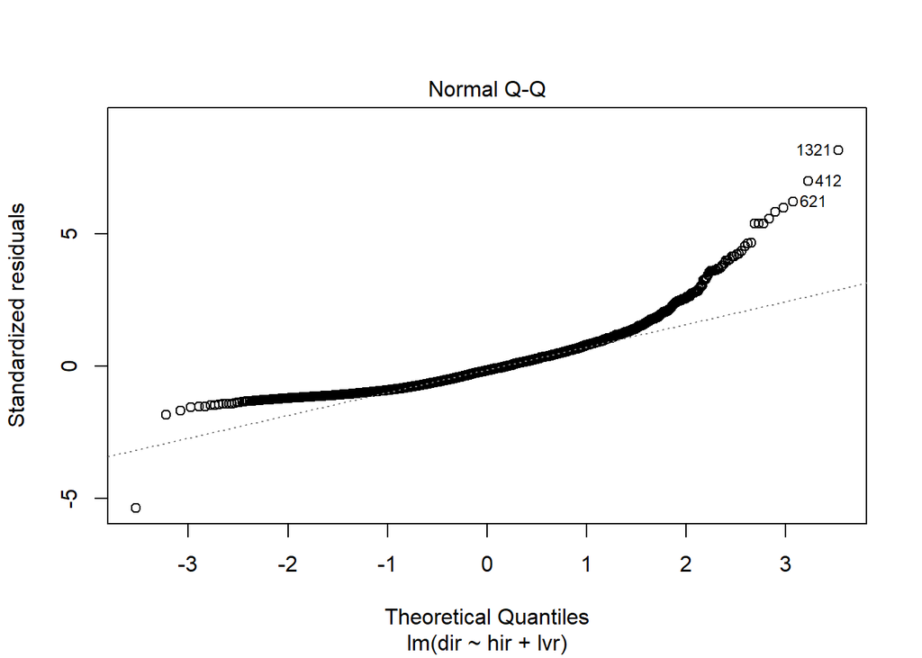

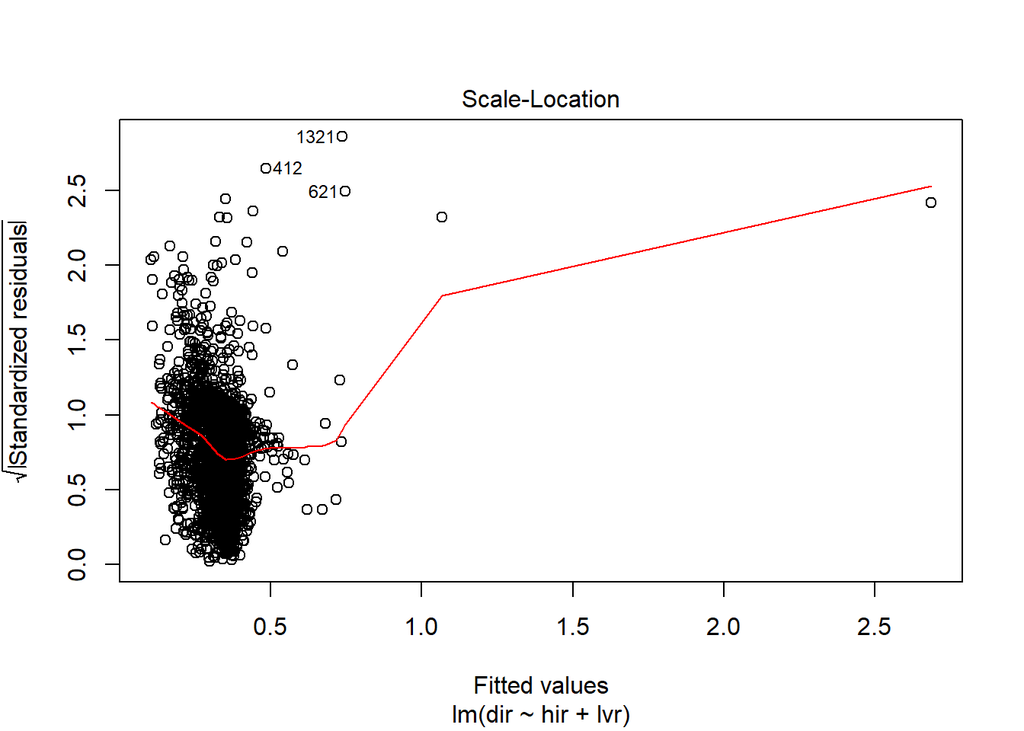

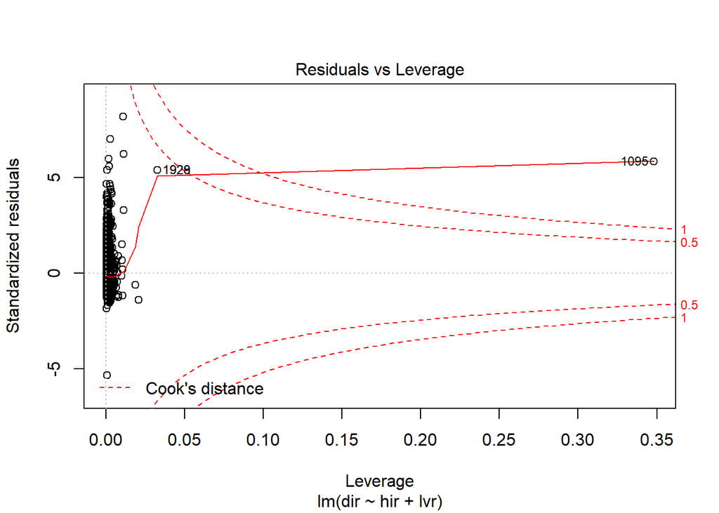

#### On ajoute deny dans le modèle

Ayant peu de variables quantitatives, nous allons tout de même ajouter *deny*, une variable qualitative, qui nous intéresse particulièrement.

La deuxième régression linéaire n’en est pas vraiment une à cause de la présence d’une variable explicative qui est qualitative, or l’AIC est un critère qui s’applique uniquement aux modèles linéaires, donc on ne peut pas l’utiliser. On utilise donc l’EQM:

# ANOVA

Le jeu de donnée contient beaucoup de variables qualitatives; effectuer une analyse de la variance pour estimer *dir* semble donc productif. Cependant il est important de noter que les résultats obtenus dans cette analyse auront un but explicatif. En effet, nous allons essayer de chercher des facteurs qui peuvent influencer *dir* mais nous ne pourrons pas utiliser ces résultats dans un but prédictif comme nous l’avons fait précédemment.

Commençons avec un modèle à un facteur. Nous aimerions savoir si *deny* impact *dir*.

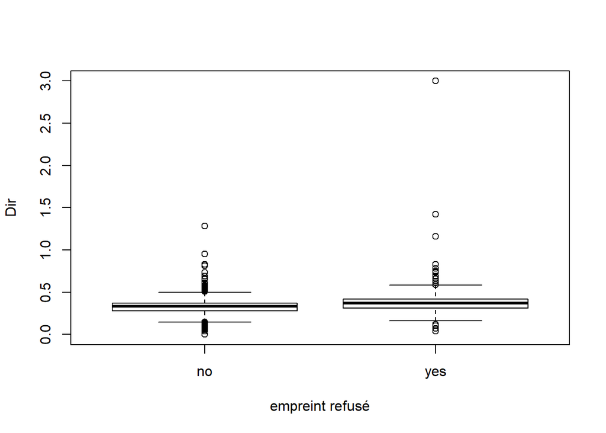

Il semblerait que la dette chez les individus qui ont obtenu leur prêt est légèrement inférieur à celle des individus du deuxième groupe. Cette différence est-elle réellement significative?

```
##
## Call:
## lm(formula = dir ~ deny, data = data)
##
## Residuals:
##      Min       1Q   Median       3Q      Max
## -0.34877 -0.04323  0.00587  0.04407  2.61123
##
## Coefficients:
##             Estimate Std. Error t value Pr(>|t|)
## (Intercept) 0.322933   0.002296 140.665   <2e-16 ***
## denyyes     0.065838   0.006636   9.922   <2e-16 ***
## ---
## Signif. codes:  0 '***' 0.001 '**' 0.01 '*' 0.05 '.' 0.1 ' ' 1
##
## Residual standard error: 0.1051 on 2379 degrees of freedom
## Multiple R-squared:  0.03974,    Adjusted R-squared:  0.03933
## F-statistic: 98.44 on 1 and 2379 DF,  p-value: < 2.2e-16
```

On constate que le test, qui suppose l’égalité entre les moyennes des deux groupes, est fortement rejeté. On pourrait conclure que si notre demande de prêt est refusée, on a plus de chance d’avoir un gros ratio dette/revenu. Cependant avant de tirer toute conclusion, vérifions que le modèle vérifie bien les conditions requises et plus précisément que les erreurs sont bien gaussiennes.

```
## [1] 62
```

Il y a seulement 62 valeurs aberrantes (sur 2381 valeurs en tout), on peut supposer que les erreurs sont bien gaussiennes et donc le modèle est valide.

```
## # A tibble: 6 x 11
##     dir   ccs   mcs pbcr  dmi   self  single  uria condominium black deny
##   <dbl> <dbl> <dbl> <chr> <chr> <chr> <chr>  <dbl>       <dbl> <chr> <chr>
## 1 0.221     5     2 no    no    no    no      3.90           0 no    no
## 2 0.265     2     2 no    no    no    yes     3.20           0 no    no
## 3 0.372     1     2 no    no    no    no      3.20           0 no    no
## 4 0.32      1     2 no    no    no    no      4.30           0 no    no
## 5 0.36      1     1 no    no    no    no      3.20           0 no    no
## 6 0.24      1     1 no    no    no    no      3.90           0 no    no
```

```
## Analysis of Variance Table
##
## Response: dir
##               Df  Sum Sq Mean Sq F value    Pr(>F)
## ccs            1  0.1165 0.11646 10.5872  0.001155 **
## mcs            1  0.0479 0.04793  4.3570  0.036963 *
## pbcr           1  0.2056 0.20564 18.6936 1.599e-05 ***
## dmi            1  0.0299 0.02993  2.7212  0.099158 .
## self           1  0.0382 0.03821  3.4733  0.062492 .
## single         1  0.0159 0.01587  1.4426  0.229843
## uria           1  0.0441 0.04405  4.0047  0.045486 *
## condominium    1  0.0157 0.01568  1.4250  0.232707
## black          1  0.0864 0.08640  7.8543  0.005111 **
## deny           1  0.7082 0.70816 64.3758 1.601e-15 ***
## Residuals   2369 26.0600 0.01100
## ---
## Signif. codes:  0 '***' 0.001 '**' 0.01 '*' 0.05 '.' 0.1 ' ' 1
```

Tout comme la régression linéaire on suppose dans l’analyse de la variance que les résidus sont gaussiens; vérifions cette hypothèse pour valider le modèle.

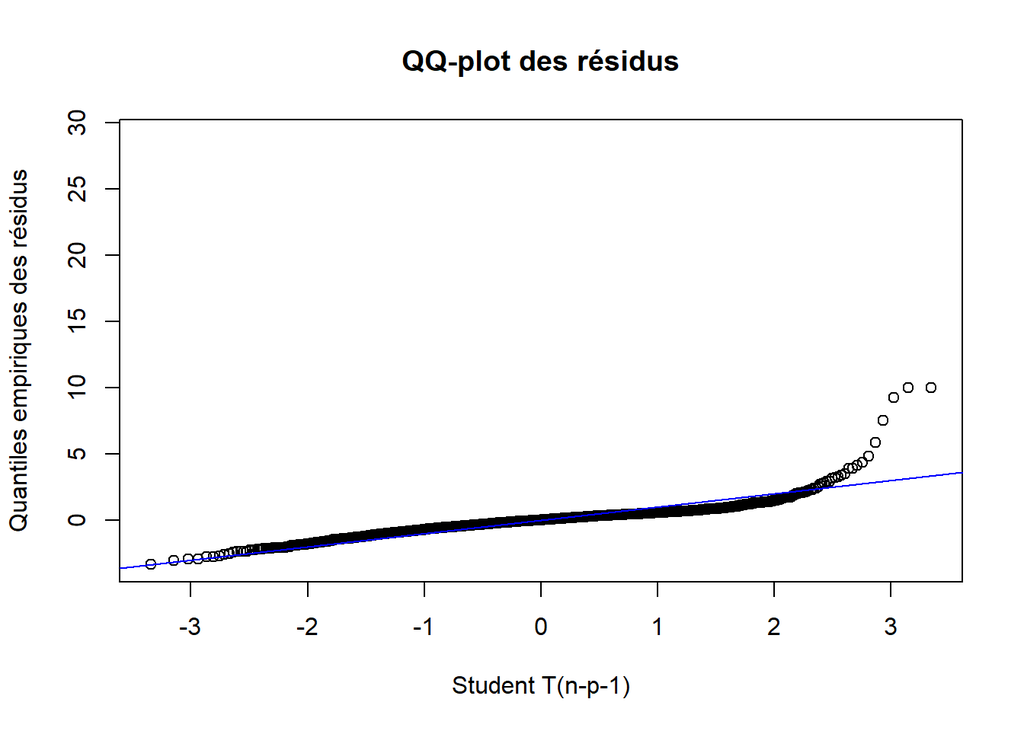

Il y a 71 résidus studentisés qui ont une valeur supérieur en valeur absolue à 2. Or si les vrais résidus suivent une loi gaussienne on devrait avoir 95% des résidus studentisés compris entre [-2,2], il y a en tout plus de 2000 résidus donc on a bien plus de 95% des résidus qui sont compris entre -2 et 2 on peut supposer l’hypothèse de normalité des résidus juste. Le modèle semble donc correct.

Cependant on aimerait aussi analyser l’interaction entre les variables explicatives mais pour cela il va falloir réduire le nombre de variables explicatives car il y a pour l’instant 10 variables. Donc en ajoutant les interaction entre chaque variables cela nous fait 2<sup>10</sup> composantes à analyser, ce qui n’est humainement pas possible.

Nous allons donc sélectionner les variables les plus pertinentes en comparant les modèles avec moins de variables. Sauf qu’il y a 10<sup>2</sup> modèles à comparer, ce qui est encore une fois inimaginable, nous allons donc utiliser une méthode descendante et éliminer à chaque étape la variable la moins pertinente d’après le test de fisher, nous montrerons les résultats des tests pour les premières variables uniquement.

Dans le modèle précédent, *Condominium* est la variable dont la p-valeur du test de fisher associé est la plus élevée on va donc la retirer du modèle.

[output not shown]

De la même manière, on retire *single*, et on réitère le procédé de l’analyse de la variance, mais en masquant les résultats de R car ceux-ci sont trop longs..

on retire *dmi*.

on retire *mcs*.

On retire *uria*.

On retire *self*.

Il nous reste donc 4 variables explicatives, l’analyse de la variance avec interaction est maintenant possible.

```
## Analysis of Variance Table
##
## Response: dir
##                       Df  Sum Sq Mean Sq F value    Pr(>F)
## ccs                    1  0.1165 0.11646 10.7572 0.0010538 **
## pbcr                   1  0.2082 0.20823 19.2335 1.207e-05 ***
## black                  1  0.0827 0.08275  7.6430 0.0057436 **
## deny                   1  0.7748 0.77478 71.5629 < 2.2e-16 ***
## ccs:pbcr               1  0.1226 0.12258 11.3217 0.0007783 ***
## ccs:black              1  0.0045 0.00447  0.4132 0.5203994
## ccs:deny               1  0.1974 0.19737 18.2305 2.035e-05 ***
## pbcr:black             1  0.0091 0.00914  0.8441 0.3583155
## pbcr:deny              1  0.0085 0.00855  0.7893 0.3744026
## black:deny             1  0.0170 0.01700  1.5699 0.2103462
## ccs:pbcr:black         1  0.0264 0.02637  2.4360 0.1187131
## ccs:pbcr:deny          1  0.1080 0.10798  9.9733 0.0016083 **
## ccs:black:deny         1  0.0253 0.02529  2.3359 0.1265518
## pbcr:black:deny        1  0.0498 0.04982  4.6012 0.0320511 *
## ccs:pbcr:black:deny    1  0.0234 0.02344  2.1653 0.1412914
## Residuals           2364 25.5941 0.01083
## ---
## Signif. codes:  0 '***' 0.001 '**' 0.01 '*' 0.05 '.' 0.1 ' ' 1
```

#### Conclusion :

On peut encore se poser une dernière question ; est ce que le modèle avec quelque variable mais aussi leur interaction et plus pertinent qu’un modèle considérant plus de variables sans leur interaction. Pour répondre à cette question nous allons comparer le dernière modèle qu’on a construit avec le modèle composé des 10 variables qualitatives du modèle. On compare donc les EQM des deux modèles.

Pour comparer les deux modèles on ne compare pas les erreurs quadratiques moyenne de prédiction (comme on l’a fait dans la regression linéaire) mais l’erreur quadratique moyenne car l’ANOVA a un but explicatif et non prédictif.

Les EQM sont très proches (0.003113688, et 0.003120243), et on conclut que le modèle avec toutes les variables explicatives approche mieux les vrais valeurs du jeu de données de test.

# Conclusion

Enfin, prédire ou expliquer la dette d’un individu suivant la réponse de sa demande de prêt ( *deny* ) peut paraître hasardeux; il serait plus logique d’effectuer l’opération inverse, c’est a dire, d’expliquer la réponse de la demande de prêt par le niveau de dette. Néanmoins, cela nécessiterait des outils plus complexes comme la régression logistique que nous n’avons pas encore aborder. Tout modèle considéré, nous pouvons conclure que notre base de donnée n’est pas la plus adaptée au modèle linéaire Gaussien, mais que celui-ci et l’ANOVA sont tout de même des outils puissants pour effectuer des prédictions ou pour expliquer des variables.

## Ouverture

```
##              black white total
## Pret accepte   243  1853  2096
## Pret Refuse     96   188   284
## total          339  2041  2380
```